# Dash for Dravet 2022

# Dash for Dravet on Turkey Day

Join us for our 1st annual Dash for Dravet!

This new family tradition has two parts: the fundraiser and the 5k trot.

The fundraiser is for our girl, Esther, and the Dravet Syndrome Foundation.

The trot is for all you turkeys 🦃 out there wanting to actively support a special cause. This 5k can be accomplished wherever you find yourself on Thanksgiving. You can walk, jog, run, roll or treadmill - it don’t matter just have fun!

# Esther

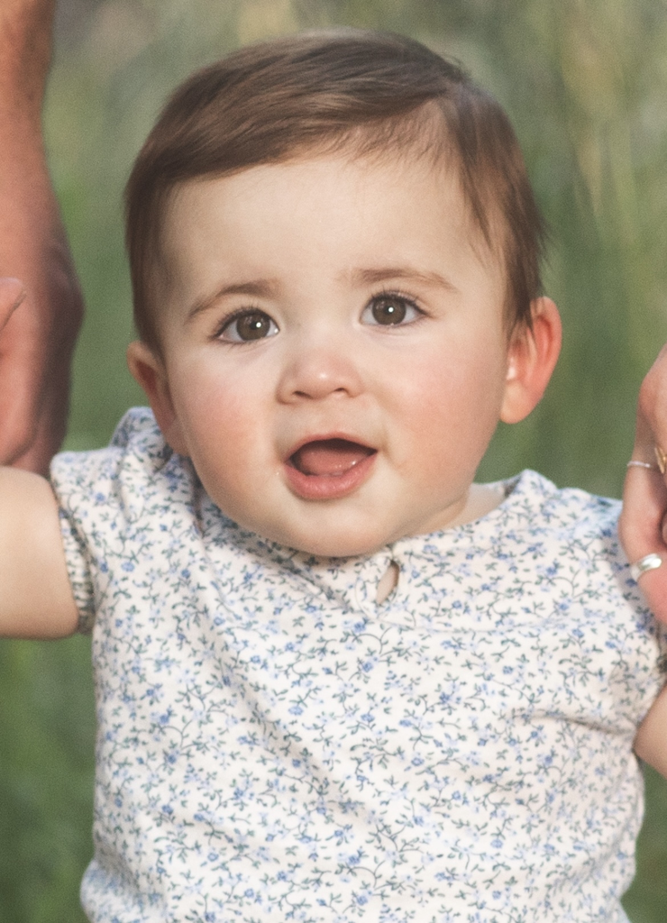

Esther G is our little queen. She’s an aspiring competitive eater by day and stuffed animal snuggler by night. She is a pro at making her mom laugh and she already has dad wrapped around her finger. Esther is brave, adventurous, and independent. She started walking this month and there’s no stopping her now. She is a cute handful and we love her 💛

Esther was diagnosed with Dravet Syndrome earlier this year. Over the past few months Grace and I have been navigating this scary and unfamiliar territory in hopes of learning as much as we can about this rare syndrome and how it will impact Esther and our family. We pray and hope for the best and thank each of you for your love, prayers, and support of our little family.

## Fundraiser

The details are super simple and we want to provide a fun turkey trot t-shirt for those wanting to contribute at these amounts:

- A donation of $50 or more scores an adult t-shirt.
- A donation of $30 or more scores a youth t-shirt.

We are happy to accept donations the entire month of November. If you are interested in a t-shirt please send your donation and t-shirt info by *5pm (MT) November 8th* that way we can get the shirt to you before the Thanksgiving trot.

[figure not shown]

Logo on long sleeve white t-shirt

## Where to donate

Scan this QR code or search *Grace Daines* on Venmo to donate.

If you donated and want a t-shirt please click the *T-shirt form* link below to provide your shipping and sizing information.

T-shirt form (no longer available)

Thank you so much 🙏

[figure not shown]

###### More Info

[Dravet Syndrome Foundation](https://dravetfoundation.org)